# Data Translation Project

Joshua Jayandran

5/16/2021

# Introduction

The research tends to utilize different dataset (King_dailyvisits & King_originvisit). The analysis was conducted through utilization of Tableau Public. In order to extract insights from the dataset data analysis was incorporated within the research. Different appropriate visualization technique was incorporated within the research which include the following visualization approaches bar charts, horizontal bar try chart and line charts. NAICS is the North American Industry Classification System.

## Story Visualization 1

The Story Visualization 1 enlightened the prospects of different highest mobile visit in over different brands, NAICS department and weekend days visit of mobile. For the very first visualization the King_dailyvisits was utilized for the purpose. Different visualization techniques are adapted such as bar charts, horizontal bar try chart and line charts.

To visualize the total visits of mobile phone for different brands during the month of July 2020 horizontal bar try representation was adapted. Through this visualization, the fact is found out that the highest number of mobiles visited are occurred in the brand industry of “**UV Medicine**”. Around **128,245 visits** were occurred in the respective industry.

To visualize the total visits of mobile phone for different NAICS department during the month of July 2020 horizontal bar try representation was adapted. Through this visualization, the fact is found out that the highest number of mobiles visited are occurred in the NAICS department of “**Hotels (except Casino Hotels) and Motels**”. Around **61,635, 285 visits** were occurred in the respective NAICS departments.

To visualize the total visits of mobile phone in weekdays during the month of July 2020 discrete vertical bar chart was adapted. Through this visualization, the fact is found out that the highest number of mobiles visited are occurred in the **week 31 of year 2020 on Friday**. Around **141,789 visits** were occurred on this day.

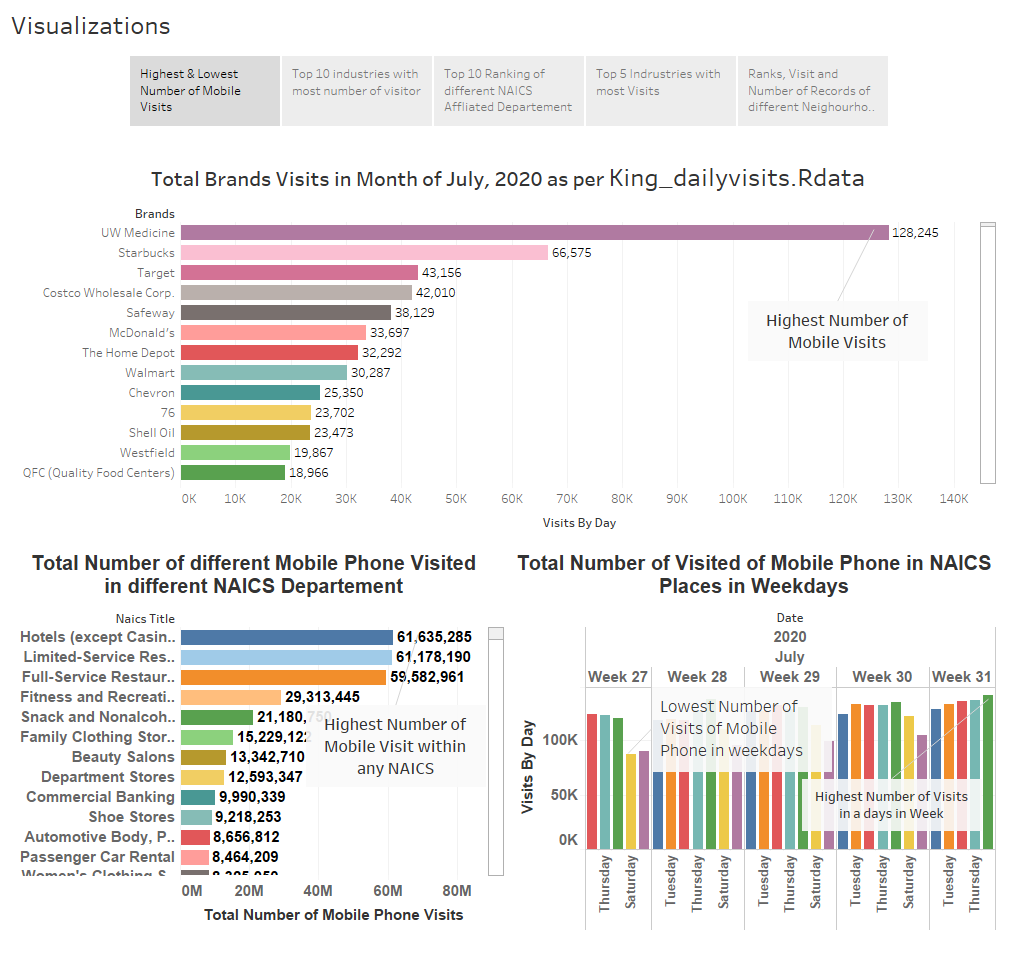

## Story Visualization 2

The Story Visualization 2 enlightened the Top 10 industries which record the greatest number of visitors after utilizing the dataset of King_Originvisits for the meant purpose. Visualization techniques of vertical Area chart was adapted for the meant purpose. Through story visualization 2 this fact is found out that limited services restaurants seem to face most number of visitors with mobile phones which are around **117,941 number of visitors**. In the Top 10 list of industries, Pharmacies and Drug Store seems to secure the last position as compared to other competitors in the top ten industries which face over **22,454 number of visitors**. Even though UW Medicine is the highest visited brand, as an industry, the General Medicine and Surgical Hospitals are the 6th most visited industry. This shows that UW Medicine is a the leading brand in the industry.

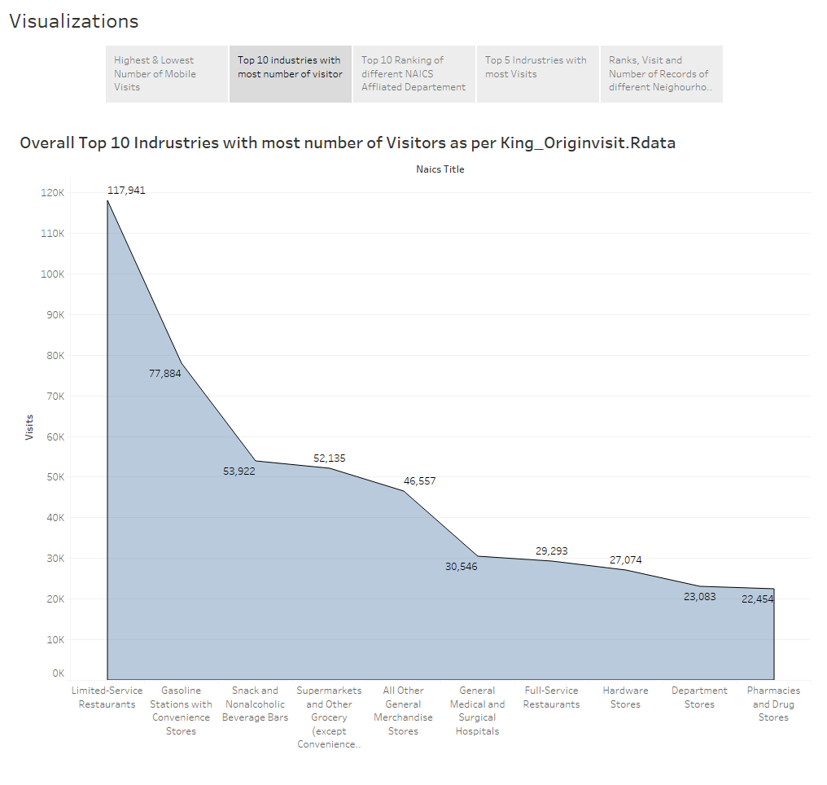

## Story Visualization 3

The Story Visualization 3 enlightened the Top 10 Ranking status of different NAICS affiliated departments. Which utilize the dataset of Kingoriginvisitsandmaps.Rdata for the meant purpose. Visualization techniques of Bubble Chart was adapted for the meant purpose. The ranking tends to enlighten statistics of different NAICS departments. These ranking are assigned by specific resources. Through visualization this fact is find out that which department acquire the most ranking are allocated to retail bakeries.In the afflicated departments, Retail Bakeries are the highest.

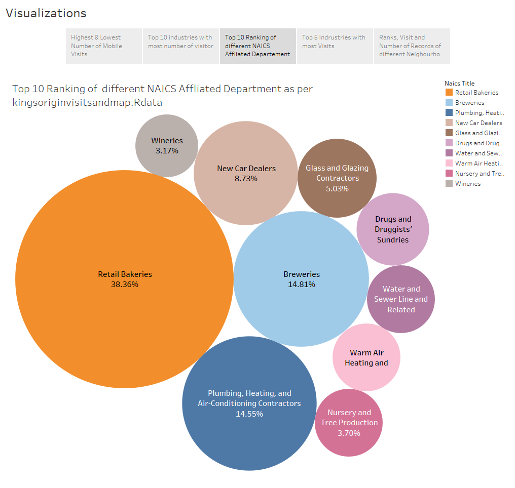

## Story Visualization 4

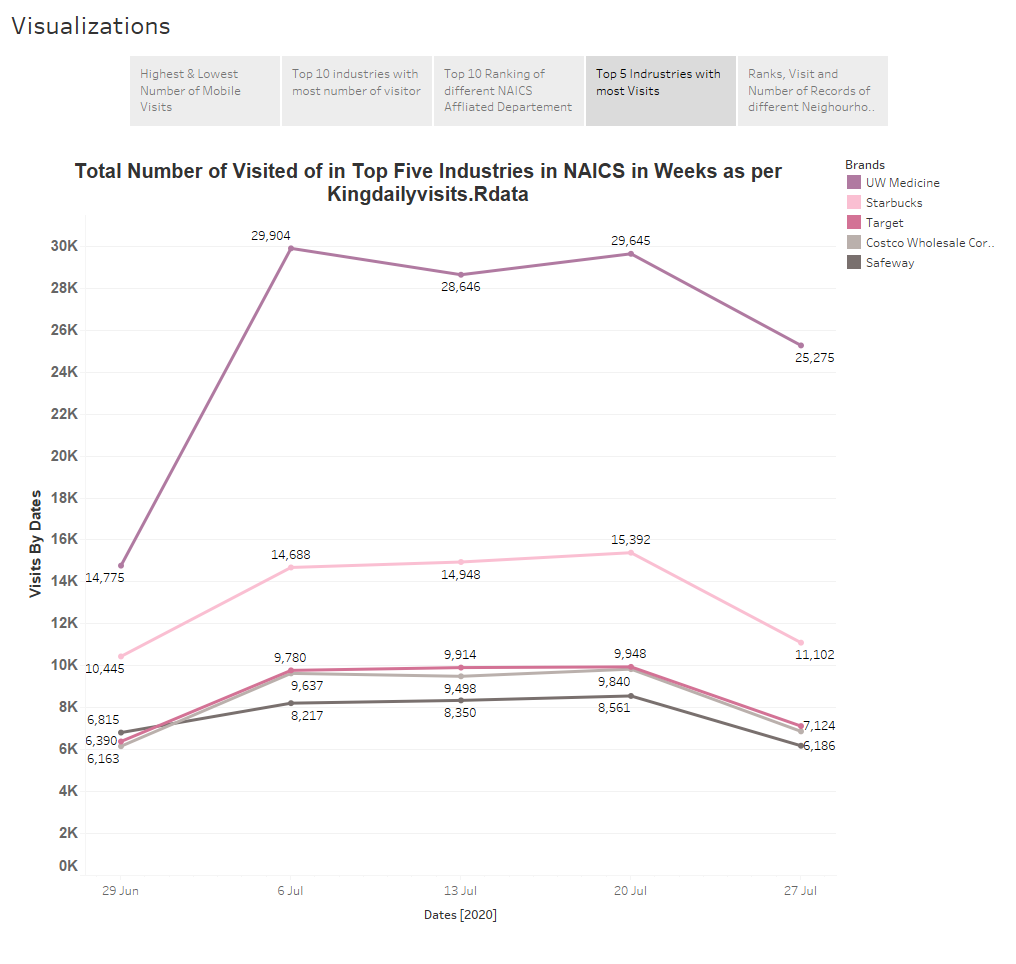

## Story Visualization 5

The Story Visualization 5 enlightened the ranks, total visits and number of records against different neighbouring district extracted from the dataset neighbourhood_names.Rdata for the meant purpose. Visualization techniques of line chart was adapted for the meant purpose. Through this visualization this fact is find out that most number of records were noticed in the region of northeast. While the least number of records were noticed in the region of downtown. Through this visualization this fact is find out that ranking was noticed in the region of northeast based departments. While the least ranking was noticed in the region of downtown based departments. Through this visualization this fact is find out that total number of visits was noticed in the region of northeast based departments. While the least number of visits in the region of downtown based departments.It is likely that the top visited brands were most likely visited in the northeast.

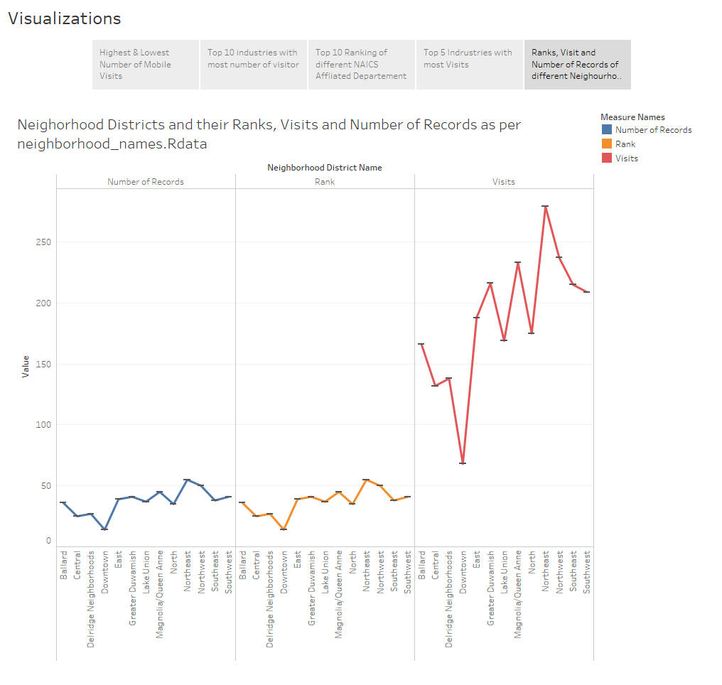